# R Notebook

# Question 3

## Import library

```r
library(tidyverse)
library(readxl)
library(caret)
library(PerformanceAnalytics)
library(car)
library(factoextra)
library(pls)
```

## Data Import

First, let us import the data.

```r
data <- read_csv("CarBig.csv")
```

## Data Exploration

We will first have a glimpse on the data

```r
dim(data)
```

```
[1] 406  13
```

```r
summary(data)
```

```
  Acceleration       cyl4             Cylinders      Displacement     Horsepower         Mfg               Model             Model_Year         MPG            org               Origin
 Min.   : 8.00   Length:406         Min.   :3.000   Min.   : 68.0   Min.   : 46.00   Length:406         Length:406         Min.   :70.00   Min.   : 9.00   Length:406         Length:406
 1st Qu.:13.70   Class :character   1st Qu.:4.000   1st Qu.:105.0   1st Qu.: 75.75   Class :character   Class :character   1st Qu.:73.00   1st Qu.:17.50   Class :character   Class :character
 Median :15.50   Mode  :character   Median :4.000   Median :151.0   Median : 95.00   Mode  :character   Mode  :character   Median :76.00   Median :23.00   Mode  :character   Mode  :character
 Mean   :15.52                      Mean   :5.475   Mean   :194.8   Mean   :105.08                                         Mean   :75.92   Mean   :23.51
 3rd Qu.:17.18                      3rd Qu.:8.000   3rd Qu.:302.0   3rd Qu.:130.00                                         3rd Qu.:79.00   3rd Qu.:29.00
 Max.   :24.80                      Max.   :8.000   Max.   :455.0   Max.   :230.00                                         Max.   :82.00   Max.   :46.60
                                                                    NA's   :6                                                              NA's   :8
     Weight         when
 Min.   :1613   Length:406
 1st Qu.:2226   Class :character
 Median :2822   Mode  :character
 Mean   :2979
 3rd Qu.:3618
 Max.   :5140
```

```r
head(data)
```

| Acceleration | cyl4 | Cylinders | Displacement | Horsepower | Mfg | Model | Model_Year | MPG | org | Origin | Weight | when |
| --- | --- | --- | --- | --- | --- | --- | --- | --- | --- | --- | --- | --- |
| 12.0 | Other | 8 | 307 | 130 | chevrolet | chevrolet chevelle malibu | 70 | 18 | USA | USA | 3504 | Early |
| 11.5 | Other | 8 | 350 | 165 | buick | buick skylark 320 | 70 | 15 | USA | USA | 3693 | Early |
| 11.0 | Other | 8 | 318 | 150 | plymouth | plymouth satellite | 70 | 18 | USA | USA | 3436 | Early |
| 12.0 | Other | 8 | 304 | 150 | amc | amc rebel sst | 70 | 16 | USA | USA | 3433 | Early |
| 10.5 | Other | 8 | 302 | 140 | ford | ford torino | 70 | 17 | USA | USA | 3449 | Early |
| 10.0 | Other | 8 | 429 | 198 | ford | ford galaxie 500 | 70 | 15 | USA | USA | 4341 | Early |

```r
str(data)
```

```
tibble [406 × 13] (S3: spec_tbl_df/tbl_df/tbl/data.frame)
 $ Acceleration: num [1:406] 12 11.5 11 12 10.5 10 9 8.5 10 8.5 ...
 $ cyl4        : chr [1:406] "Other" "Other" "Other" "Other" ...
 $ Cylinders   : num [1:406] 8 8 8 8 8 8 8 8 8 8 ...
 $ Displacement: num [1:406] 307 350 318 304 302 429 454 440 455 390 ...
 $ Horsepower  : num [1:406] 130 165 150 150 140 198 220 215 225 190 ...
 $ Mfg         : chr [1:406] "chevrolet" "buick" "plymouth" "amc" ...
 $ Model       : chr [1:406] "chevrolet chevelle malibu" "buick skylark 320" "plymouth satellite" "amc rebel sst" ...
 $ Model_Year  : num [1:406] 70 70 70 70 70 70 70 70 70 70 ...
 $ MPG         : num [1:406] 18 15 18 16 17 15 14 14 14 15 ...
 $ org         : chr [1:406] "USA" "USA" "USA" "USA" ...
 $ Origin      : chr [1:406] "USA" "USA" "USA" "USA" ...
 $ Weight      : num [1:406] 3504 3693 3436 3433 3449 ...
 $ when        : chr [1:406] "Early" "Early" "Early" "Early" ...
 - attr(*, "spec")=
  .. cols(
  ..   Acceleration = col_double(),
  ..   cyl4 = col_character(),
  ..   Cylinders = col_double(),
  ..   Displacement = col_double(),
  ..   Horsepower = col_double(),
  ..   Mfg = col_character(),
  ..   Model = col_character(),
  ..   Model_Year = col_double(),
  ..   MPG = col_double(),
  ..   org = col_character(),
  ..   Origin = col_character(),
  ..   Weight = col_double(),
  ..   when = col_character()
  .. )
```

This data set has 13 variables. First, we can convert the categorical data to factors for easier manipulation later and determine the variables that are unnecessary.

```r
data$cyl4 <- as.factor(data$cyl4)
data$Mfg <- as.factor(data$Mfg)
data$Origin <- as.factor(data$Origin)
data$org <- as.factor(data$org)
data$when <- as.factor(data$when)
data$Model_Year <- as.factor(data$Model_Year)
```

Then we re-inspect the data.

```r
str(data)
```

```
tibble [406 × 13] (S3: spec_tbl_df/tbl_df/tbl/data.frame)
 $ Acceleration: num [1:406] 12 11.5 11 12 10.5 10 9 8.5 10 8.5 ...
 $ cyl4        : Factor w/ 2 levels "Four","Other": 2 2 2 2 2 2 2 2 2 2 ...
 $ Cylinders   : num [1:406] 8 8 8 8 8 8 8 8 8 8 ...
 $ Displacement: num [1:406] 307 350 318 304 302 429 454 440 455 390 ...
 $ Horsepower  : num [1:406] 130 165 150 150 140 198 220 215 225 190 ...
 $ Mfg         : Factor w/ 30 levels "amc","audi","bmw",..: 6 4 22 1 12 12 6 22 23 1 ...
 $ Model       : chr [1:406] "chevrolet chevelle malibu" "buick skylark 320" "plymouth satellite" "amc rebel sst" ...
 $ Model_Year  : Factor w/ 13 levels "70","71","72",..: 1 1 1 1 1 1 1 1 1 1 ...
 $ MPG         : num [1:406] 18 15 18 16 17 15 14 14 14 15 ...
 $ org         : Factor w/ 3 levels "Europe","Japan",..: 3 3 3 3 3 3 3 3 3 3 ...
 $ Origin      : Factor w/ 7 levels "England","France",..: 7 7 7 7 7 7 7 7 7 7 ...
 $ Weight      : num [1:406] 3504 3693 3436 3433 3449 ...
 $ when        : Factor w/ 3 levels "Early","Late",..: 1 1 1 1 1 1 1 1 1 1 ...
 - attr(*, "spec")=
  .. cols(
  ..   Acceleration = col_double(),
  ..   cyl4 = col_character(),
  ..   Cylinders = col_double(),
  ..   Displacement = col_double(),
  ..   Horsepower = col_double(),
  ..   Mfg = col_character(),
  ..   Model = col_character(),
  ..   Model_Year = col_double(),
  ..   MPG = col_double(),
  ..   org = col_character(),
  ..   Origin = col_character(),
  ..   Weight = col_double(),
  ..   when = col_character()
  .. )
```

We can see that `cyl4` is just another presentation of variable `Cylinders` stating whether its 4 cylinder, hence we do not need the variable `cyl4`. Next, we see that `org` and `Origin` are virtually describing the same variable. Hence, we keep the variable `org` instead of `Origin` as we want the European countries to be represented under the factor `Europe`. We will drop `when` variable too as it only describe when in the year the car is released.

```r
data <- select(data, -c(cyl4, Origin, when))
str(data)
```

```
tibble [406 × 10] (S3: tbl_df/tbl/data.frame)
 $ Acceleration: num [1:406] 12 11.5 11 12 10.5 10 9 8.5 10 8.5 ...
 $ Cylinders   : num [1:406] 8 8 8 8 8 8 8 8 8 8 ...
 $ Displacement: num [1:406] 307 350 318 304 302 429 454 440 455 390 ...
 $ Horsepower  : num [1:406] 130 165 150 150 140 198 220 215 225 190 ...
 $ Mfg         : Factor w/ 30 levels "amc","audi","bmw",..: 6 4 22 1 12 12 6 22 23 1 ...
 $ Model       : chr [1:406] "chevrolet chevelle malibu" "buick skylark 320" "plymouth satellite" "amc rebel sst" ...
 $ Model_Year  : Factor w/ 13 levels "70","71","72",..: 1 1 1 1 1 1 1 1 1 1 ...
 $ MPG         : num [1:406] 18 15 18 16 17 15 14 14 14 15 ...
 $ org         : Factor w/ 3 levels "Europe","Japan",..: 3 3 3 3 3 3 3 3 3 3 ...
 $ Weight      : num [1:406] 3504 3693 3436 3433 3449 ...
```

We will do some quick exploratory plotting on the numerical data.

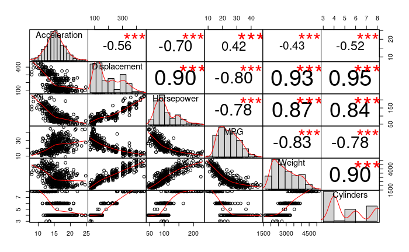

```r
select(data, Acceleration, Displacement, Horsepower, MPG, Weight, Cylinders) %>%
  chart.Correlation(histogram = TRUE, pch = 19)
```

We will now do some plotting to see how the categorical data fits in the scatter plot.

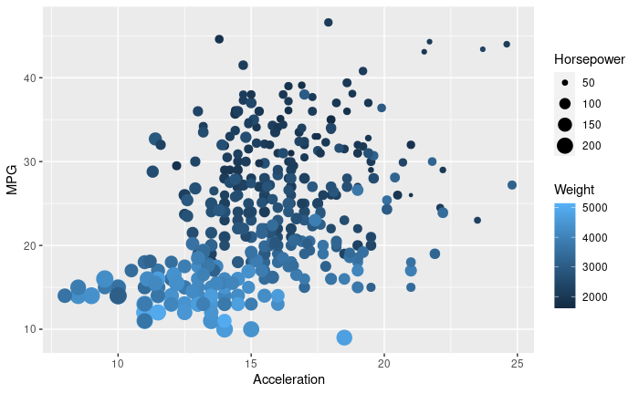

```r
ggplot(data)+
  geom_point(aes(x = Acceleration, y = MPG, color = Weight, size = Horsepower))
```

From the plot, we can see that usually cars with higher `Weight` have lower `MPG` and `Acceleration` probably due to more fuel and force is needed to carry the higher weight.

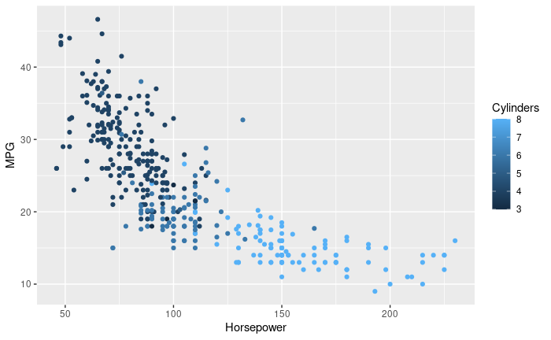

```r
ggplot(data)+
  geom_point(aes(x = Horsepower, y = MPG, color = Cylinders))
```

Now from this plot, we can see that cars with more `Cylinders` tends to have more `Horsepower`, which makes sense and lower `MPG`. This might due to the increase in weight causing more insufficient consumption of fuel.

Next, we are interested to see how `MPG`, `Horsepower`, `Weight` and `org` is correlated to each other. We are interested to see country from which origin has the highest miles-per-gallon and horsepower.

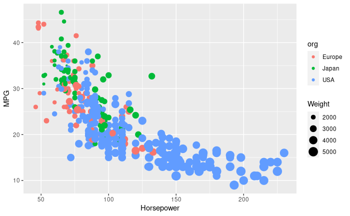

```r
ggplot(data)+
  geom_point(aes(x = Horsepower, y = MPG, size = Weight, color = org))
```

We can see that most cars from Europe and Japan has smaller weight, greater `MPG` and lesser `Horsepower`. The small weight inferred that the car is more compact, less cylinders in the engine which leads to lower `Horsepower` but greater performance in terns of fuel saving `MPG`.

## Data transformation while doing linear fitting

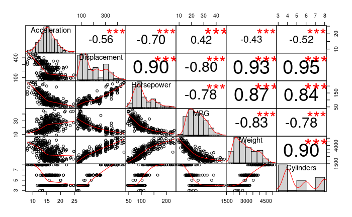

```r
select(data, Acceleration, Displacement, Horsepower, MPG, Weight, Cylinders) %>%
  chart.Correlation(histogram = TRUE, pch = 19)
```

Observing from this graph and having `MPG` as our output, we can do some transformation to the features. We see that `Displacement`, `Horsepower`, `Weight` and `Cylinders` are inversely proportional to `MPG`, hence we will do a $1/x$ transformation to these features. However, due to the nature that `Displacement`, `Horsepower`, `Weight` and `Cylinders` are highly correlated, we expect that only one is needed in the end. We will do ANOVA test to compare model fitting. The categorical variables `Model`, `Mfg` and `Model_Year` of the car are not needed in the linear regression as they are already shown to reflect their effect through the numerical variable as shown in previous exploratory analysis.

### Data radomizing

First, we will shuffle our data so that the data is not sorted in any patterns.

```r
set.seed(100)
data <- data %>%
  mutate(rand = runif(dim(data)[1])) %>%
  arrange(rand)

head(data)
```

| Acceleration | Cylinders | Displacement | Horsepower | Mfg | Model | Model_Year | MPG | org | Weight | rand |
| --- | --- | --- | --- | --- | --- | --- | --- | --- | --- | --- |
| 16.0 | 6 | 198 | 95 | plymouth | plymouth duster | 73 | 23.0 | USA | 2904 | 0.01154550 |
| 17.0 | 6 | 250 | 100 | chevrolet | chevrolet nova | 74 | 15.0 | USA | 3336 | 0.01618339 |
| 13.6 | 6 | 163 | 125 | volvo | volvo 264gl | 78 | 17.0 | Europe | 3140 | 0.01631959 |
| 16.0 | 4 | 79 | 67 | fiat | fiat x1.9 | 74 | 31.0 | Europe | 2000 | 0.01902087 |
| 16.5 | 4 | 98 | 83 | audi | audi fox | 74 | 29.0 | Europe | 2219 | 0.01959930 |
| 16.9 | 4 | 79 | 58 | toyota | toyota starlet | 81 | 39.1 | Japan | 1755 | 0.02058322 |

Then we subset out the features that are needed. Here we subset the columns `Acceleration`, `Cylinders`, `Displacement`, `Horsepower`, `MPG`, and `Weight`.

```r
data <- data %>%
  select(-c(Mfg, Model, Model_Year, org, rand)) %>% # unselect the stated features
  mutate(invCylinders = 1/Cylinders,
         invHorsepower = 1/Horsepower,
         invDisplacement = 1/Displacement,
         invWeight = 1/Weight)
```

### Training and test set

Next, we split our data into 80% training set and 20% test set.

```r
dim(data)
```

```
[1] 406  10
```

As we can see, there are 406 observations. Hence, we will select top 325(~80%) out of the randomized data as training set and the remaining (81) as test set.

```r
trainingSet <- head(data, 325)
testSet <- tail(data, 81)
```

### Linear fitting

Now, we will do our linear fitting with all the variables with the $1/x$ transformation applied to `Horsepower`, `Displacement`, and `Weight`. We will be omitting observations with NaN values.

$\hat{MPG_1}=\hat{\beta_0}+\hat{\beta_1}\cdot Acceleration + \hat{\beta_2}\cdot \frac{1}{Cylinders} +\hat{\beta_3}\cdot\frac{1}{Displacement} +\hat{\beta_4}\cdot \frac{1}{Horsepower} + \hat{\beta_5}\cdot \frac{1}{Weight}$

```r
model1 <- train(MPG ~ Acceleration + invCylinders + invDisplacement +
                  invHorsepower + invWeight,
                data = trainingSet,
                na.action = na.omit,
                method = "lm")

model1
```

```
Linear Regression

325 samples
  5 predictor

No pre-processing
Resampling: Bootstrapped (25 reps)
Summary of sample sizes: 313, 313, 313, 313, 313, 313, ...
Resampling results:

  RMSE      Rsquared   MAE
  4.046183  0.7223438  2.865045

Tuning parameter 'intercept' was held constant at a value of TRUE
```

```r
summary(model1)
```

```
Call:
lm(formula = .outcome ~ ., data = dat)

Residuals:
     Min       1Q   Median       3Q      Max
-13.2089  -2.1431  -0.4048   1.6893  15.5164

Coefficients:
                  Estimate Std. Error t value Pr(>|t|)
(Intercept)         2.7692     2.2270   1.243  0.21465
Acceleration       -0.2975     0.1316  -2.260  0.02450 *
invCylinders       27.9394     8.9500   3.122  0.00197 **
invDisplacement    -1.7786   238.4798  -0.007  0.99405
invHorsepower    1042.0009   179.9871   5.789 1.75e-08 ***
invWeight       23707.3155  8002.1641   2.963  0.00329 **
---
Signif. codes:  0 ‘***’ 0.001 ‘**’ 0.01 ‘*’ 0.05 ‘.’ 0.1 ‘ ’ 1

Residual standard error: 3.858 on 307 degrees of freedom
Multiple R-squared:  0.7497,    Adjusted R-squared:  0.7457
F-statistic: 183.9 on 5 and 307 DF,  p-value: < 2.2e-16
```

Now we will do VIF test and with p-values of the t-statistics to decide which features to drop.

```r
vif(model1$finalModel)
```

```
   Acceleration    invCylinders invDisplacement   invHorsepower       invWeight
       2.880576        5.383775       12.697533        8.173212       12.856060
```

$\hat{MPG_2}=\hat{\beta_0}+\hat{\beta_1}\cdot Acceleration + \hat{\beta_2}\cdot \frac{1}{Cylinders} + \hat{\beta_3}\cdot \frac{1}{Horsepower} + \hat{\beta_4}\cdot \frac{1}{Weight}$

```r
model2 <- train(MPG ~ Acceleration + invCylinders +
                  invHorsepower + invWeight,
                data = trainingSet,
                na.action = na.omit,
                method = "lm")

model2
```

```
Linear Regression

325 samples
  4 predictor

No pre-processing
Resampling: Bootstrapped (25 reps)
Summary of sample sizes: 313, 313, 313, 313, 313, 313, ...
Resampling results:

  RMSE      Rsquared   MAE
  3.921619  0.7400887  2.794985

Tuning parameter 'intercept' was held constant at a value of TRUE
```

```r
summary(model2)
```

```
Call:
lm(formula = .outcome ~ ., data = dat)

Residuals:
     Min       1Q   Median       3Q      Max
-13.2063  -2.1429  -0.4058   1.6888  15.5194

Coefficients:
                Estimate Std. Error t value Pr(>|t|)
(Intercept)       2.7798     1.7080   1.627 0.104661
Acceleration     -0.2976     0.1299  -2.291 0.022617 *
invCylinders     27.9033     7.5224   3.709 0.000246 ***
invHorsepower  1042.0461   179.5928   5.802 1.62e-08 ***
invWeight     23669.6757  6200.0020   3.818 0.000163 ***
---
Signif. codes:  0 ‘***’ 0.001 ‘**’ 0.01 ‘*’ 0.05 ‘.’ 0.1 ‘ ’ 1

Residual standard error: 3.852 on 308 degrees of freedom
Multiple R-squared:  0.7497,    Adjusted R-squared:  0.7465
F-statistic: 230.7 on 4 and 308 DF,  p-value: < 2.2e-16
```

We see that the model performance has increased from $R^2_{adj}=0.7457$ to $R^2_{adj}=0.7465$. We will do an ANOVA test to see if both model1 and model2 are performing equally well.

```r
anova(model1$finalModel, model2$finalModel)
```

```
Analysis of Variance Table

Model 1: .outcome ~ Acceleration + invCylinders + invDisplacement + invHorsepower +
    invWeight
Model 2: .outcome ~ Acceleration + invCylinders + invHorsepower + invWeight
  Res.Df    RSS Df  Sum of Sq     F Pr(>F)
1    307 4569.2
2    308 4569.2 -1 -0.0008279 1e-04 0.9941
```

The ANOVA test has a $p=0.9941$ implying that we cannot reject the null hypothesis that both model are performing equally well. We do not have sufficient evidence that model2 is performing better than model1 with the training data.

Now, we run again VIF test for model2.

```r
vif(model2$finalModel)
```

```
 Acceleration  invCylinders invHorsepower     invWeight
     2.815016      3.815628      8.163947      7.742637
```

Through the VIF test, we can see that `invHorsepower` and `invWeight` are highly correlated of value greater than 5. We will remove the term `invWeight` as it has a higher p-values for t-statistics to avoid multi-collinearity problem.

$\hat{MPG_3}=\hat{\beta_0}+\hat{\beta_1}\cdot Acceleration + \hat{\beta_2}\cdot \frac{1}{Cylinders} + \hat{\beta_3}\cdot \frac{1}{Horsepower}$

```r
model3 <- train(MPG ~ Acceleration + invCylinders + invHorsepower,
                data = trainingSet,
                na.action = na.omit,
                method = "lm")

model3
```

```
Linear Regression

325 samples
  3 predictor

No pre-processing
Resampling: Bootstrapped (25 reps)
Summary of sample sizes: 313, 313, 313, 313, 313, 313, ...
Resampling results:

  RMSE      Rsquared   MAE
  4.022711  0.7259492  2.876827

Tuning parameter 'intercept' was held constant at a value of TRUE
```

```r
summary(model3)
```

```
Call:
lm(formula = .outcome ~ ., data = dat)

Residuals:
     Min       1Q   Median       3Q      Max
-13.9377  -2.1157  -0.3558   1.6382  15.2553

Coefficients:
               Estimate Std. Error t value Pr(>|t|)
(Intercept)      6.7189     1.3908   4.831 2.14e-06 ***
Acceleration    -0.5700     0.1109  -5.139 4.91e-07 ***
invCylinders    45.0925     6.1570   7.324 2.11e-12 ***
invHorsepower 1546.9667   124.1363  12.462  < 2e-16 ***
---
Signif. codes:  0 ‘***’ 0.001 ‘**’ 0.01 ‘*’ 0.05 ‘.’ 0.1 ‘ ’ 1

Residual standard error: 3.935 on 309 degrees of freedom
Multiple R-squared:  0.7379,    Adjusted R-squared:  0.7353
F-statistic:   290 on 3 and 309 DF,  p-value: < 2.2e-16
```

Now we see that the model3 has a slightly smaller $R^2_{adj}=0.7353$. We will run an ANOVA test to see if model3 performs equally well to model2.

```r
anova(model2$finalModel, model3$finalModel)
```

```
Analysis of Variance Table

Model 1: .outcome ~ Acceleration + invCylinders + invHorsepower + invWeight
Model 2: .outcome ~ Acceleration + invCylinders + invHorsepower
  Res.Df    RSS Df Sum of Sq      F    Pr(>F)
1    308 4569.2
2    309 4785.4 -1   -216.22 14.575 0.0001629 ***
---
Signif. codes:  0 ‘***’ 0.001 ‘**’ 0.01 ‘*’ 0.05 ‘.’ 0.1 ‘ ’ 1
```

The ANOVA test has a $p=0.0001629<0.005$ implying that we have sufficient evidence to reject the null hypothesis that model2 and model3 performs equally well.

However, one problem to note that there might be a multi-collinearity problem in model2 observing from the VIF test, which might in turn affects the validity of p-values for the ANOVA test. The slight drop in $R^2_{adj}$ worth the reduction in the multi-collinearity problem. Hence, we will keep model3 as a better model than model2.

Since `Horsepower` is non-linear, we will try to fit `Horsepower` to the 2nd order polynomial instead of $1/x$.

$\hat{MPG_4}=\hat{\beta_0}+\hat{\beta_1}\cdot Acceleration + \hat{\beta_2}\cdot \frac{1}{Cylinders} + \hat{\beta_3}\cdot Horsepower + \hat{\beta_4}\cdot Horsepower^2$

```r
model4 <- trainingSet %>%
  mutate(Horsepower2 = Horsepower^2) %>%
  train(MPG ~  Acceleration + invCylinders + Horsepower + Horsepower2,
                data = .,
                na.action = na.omit,
                method = "lm")

model4
summary(model4)
```

[output not shown]

So far model2 has the higher $R^2_{adj}$ but it suffers multi-collinearity problem. Hence, the next model with highest training $R^2_{adj}$ is model3.

## Regress on test set

Now, we will apply our model3 and model4 on test set and observe their performance. Model1 and model2 are not being considered due to multi-collienarity problem. First, we will create the metric reporting function that reports `RMSE`, `R2` and `R2_adj`.

```r
metric <- function(raw, predict, nPredictor, dp = 5){
  n <- length(predict)
  SSE <- sum((raw - predict) ^ 2)
  SST <- sum((raw - (sum(raw)/n)) ^ 2)
  R2 <- 1 - SSE/SST
  R2adj <- 1 - (((1 - R2)*(n - 1))/(n - nPredictor - 1))
  RMSE <- sqrt(SSE/n)
  table <- data.frame(cbind(n, round(SSE,dp), round(SST,dp), round(R2,dp),
             round(R2adj,dp), round(RMSE,dp)))
  colnames(table) <- c("n","SSE","SST","R2","R2adj","RMSE")
  return(table)
}
```

```r
predictModel3 <- na.omit(testSet) %>%
  predict(model3, .)

predictModel4 <- na.omit(testSet) %>%
  mutate(Horsepower2 = Horsepower^2) %>%
  predict(model4, .)

metricModel3 <- metric(na.omit(testSet)$MPG, predictModel3, length(model3$finalModel$coefficients)-1)
metricModel4 <- metric(na.omit(testSet)$MPG, predictModel4, length(model4$finalModel$coefficients)-1)
rbind(metricModel3, metricModel4)
```

| n | SSE | SST | R2 | R2adj | RMSE |
| --- | --- | --- | --- | --- | --- |
| 79 | 1457.202 | 5549.807 | 0.73743 | 0.72693 | 4.29483 |
| 79 | 1445.988 | 5549.807 | 0.73945 | 0.72537 | 4.27828 |

We can see that both model3 and model4 performs roughly equally well according to the $R^2_{adj}$ generated.

## Principal Component Analysis

We will be doing PCR. First, we will get the Training Set and Test set again, and select only relevant variables.

```r
testSet <- na.omit(testSet)
trainingSet <- na.omit(trainingSet)
```

Then we will perform PCA

```r
# PCA SVD method
pcr1 <- trainingSet %>%
  select(Acceleration, Cylinders, Displacement, Horsepower, MPG, Weight) %>%
  pcr(MPG ~., data = ., scale = TRUE)

summary(pcr1)
```

```
Data:   X dimension: 313 5
    Y dimension: 313 1
Fit method: svdpc
Number of components considered: 5
TRAINING: % variance explained
     1 comps  2 comps  3 comps  4 comps  5 comps
X      81.43    95.25    97.93    99.23   100.00
MPG    66.87    69.79    70.49    70.71    70.91
```

According to PCA, with 95% variance, only 2 PCA component is needed, with a cumulative variance percent of 95.25%.

```r
pcrPredict1 <- predict(pcr1, testSet, ncomp = 2)
metric(testSet$MPG, pcrPredict1, length(pcr1$coefficients)-1)
```

| n | SSE | SST | R2 | R2adj | RMSE |
| --- | --- | --- | --- | --- | --- |
| 79 | 1807.793 | 5549.807 | 0.67426 | 0.52949 | 4.78367 |

We can see that PCR without the transformed variables does not perform as well compared to the linear regression with transformed variable with that significantly smaller $R^2_{adj}$ value.

### PCR with transformed variable

Since PCR does not work well if the variables are not linear, we will try again PCR with the linearly transformed variables: `invWeight`, `invCylinders`, `invHorsepower`, and `invDisplacement`.

```r
pcr2 <- trainingSet %>%
  select(Acceleration, invCylinders, invDisplacement, invHorsepower, MPG, invWeight) %>%
  pcr(MPG ~., data = ., scale = TRUE)

summary(pcr2)
```

```
Data:   X dimension: 313 5
    Y dimension: 313 1
Fit method: svdpc
Number of components considered: 5
TRAINING: % variance explained
     1 comps  2 comps  3 comps  4 comps  5 comps
X      77.97    93.40    97.49    99.15   100.00
MPG    71.31    72.91    74.09    74.96    74.97
```

With the inverse variables, we can see that with a threshold variance of 95%, 3 components must be chosen with a accumulated 97.49% of variance explained.

```r
pcrPredict2 <- predict(pcr2, testSet, ncomp = 3)
metric(testSet$MPG, pcrPredict2, length(pcr2$coefficients)-1)
```

| n | SSE | SST | R2 | R2adj | RMSE |
| --- | --- | --- | --- | --- | --- |
| 79 | 1387.203 | 5549.807 | 0.75004 | 0.63895 | 4.19041 |

From the metric generated, we can see that PCR with transformed variable performed better than PCR without transformed variable. This is probably due to the fact that the transformed variables are more closed to linear variable and the PCA algorithm we work with works on linear variable.